# Exploratory Data Analysis by Visualization

Let’s first load the **Iris** dataset. This is a very famous dataset in almost all data mining, machine learning courses, and it has been an R build-in dataset. The dataset consists of 50 samples from each of three species of Iris flowers (Iris setosa, Iris virginicaand Iris versicolor). Four features(variables) were measured from each sample, they are the **length** and the **width** of sepal and petal, in centimeters. It is introduced by Sir Ronald Fisher in 1936.

- 3 Species

- Four features of flower: **length** and the **width** of sepal and petal

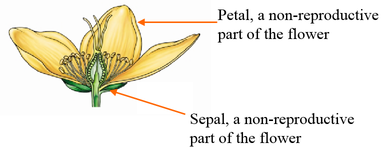

# 1 Exploratory Data Analysis by Visualization

## 1.1 Histogram

Histogram is the easiest way to show how **numerical** variables are distributed.

#### 1.1.0.1 Produce a single histogram

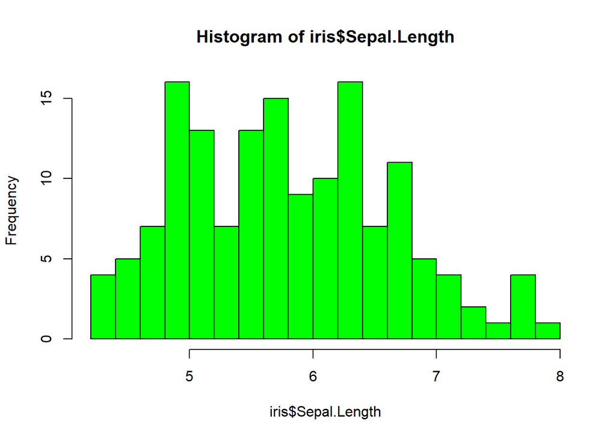

```r
data(iris)
hist(iris$Sepal.Length, col="green", breaks=20)
```

You may change “breaks=” and “col=” to have different appearance.

#### 1.1.0.2 Density plot – Fitted curve for histogram

Density plot is a nonparametric fitting.

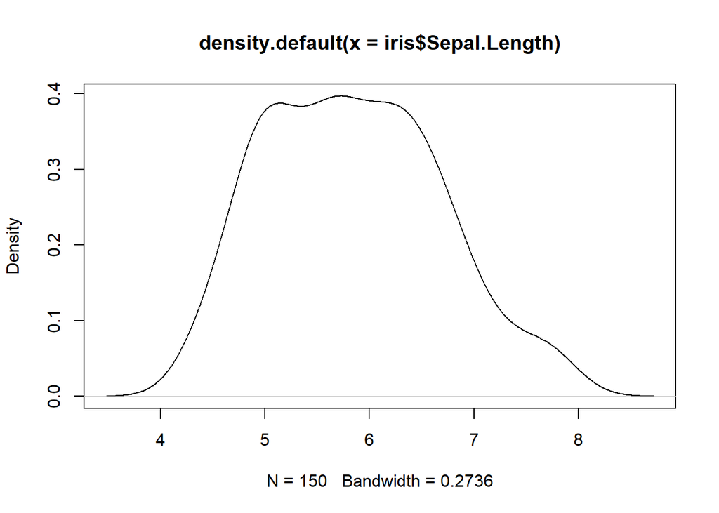

```r
plot(density(iris$Sepal.Length))
```

#### 1.1.0.3 Combine the histogram and the density chart.

You can make the plot more elegant with different options. For example, adding a title, adjusting the axis range, renaming the axis label, and so on…

You can also add curves on top of an existing plot by using `lines()` or `abline()` function.

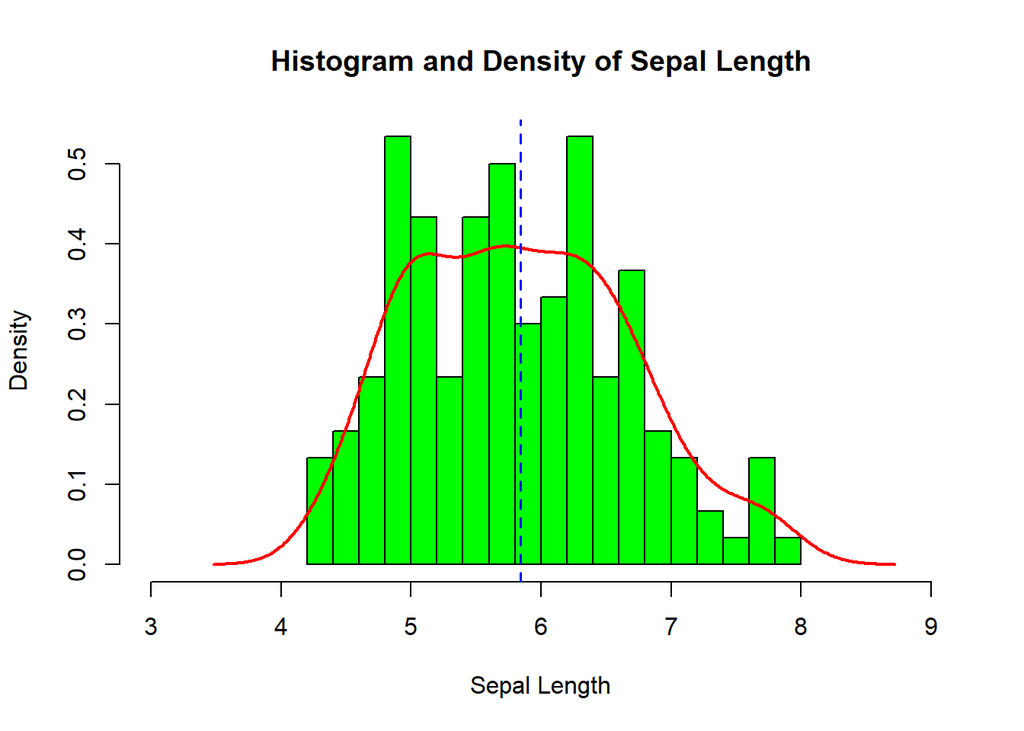

```r
hist(iris$Sepal.Length, prob=T, col="green", breaks=20, main="Histogram and Density of Sepal Length", xlim=c(3,9), xlab="Sepal Length")
lines(density(iris$Sepal.Length), col="red", lwd=2)

# Add a vertical line that indicates the average of Sepal Length
abline(v=mean(iris$Sepal.Length), col="blue", lty=2, lwd=1.5)
```

## 1.2 Bar Chart

Bar chart is produces by using a vector of single data points, which is often a vector of summary statistics. Therefore, you need to preprocess your data, and get summary statistics before drawing the bar chart.

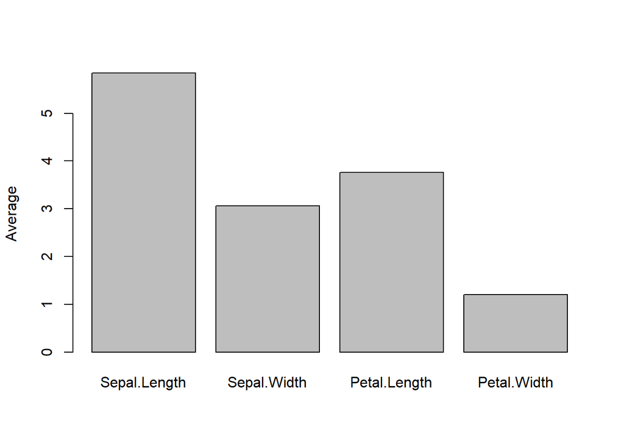

```r
# bar chart for average of the 4 quantitative variables
aveg<- apply(iris[,1:4], 2, mean)
barplot(aveg, ylab = "Average")
```

#### 1.2.0.1 Use `?barplot` or Google search to produce following bar chart.

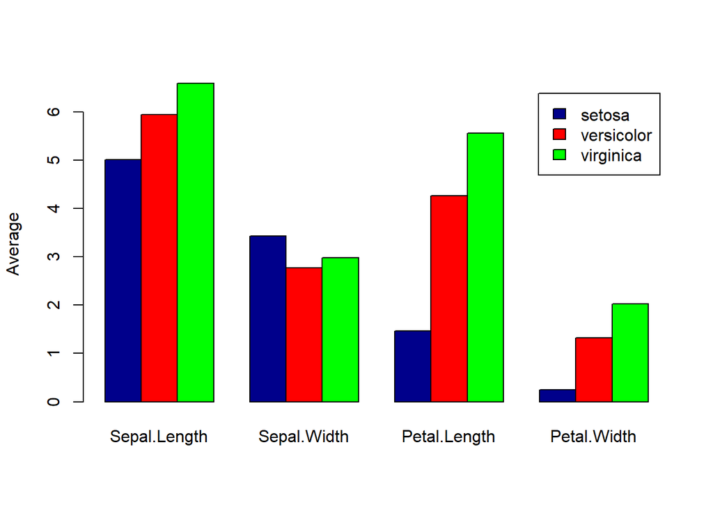

## 1.3 Pie Chart

Pie chart is commonly used to visualize the proportion of different subject. It is similar to bar chart. You have to use a vector of single data points to produce a pie chart.

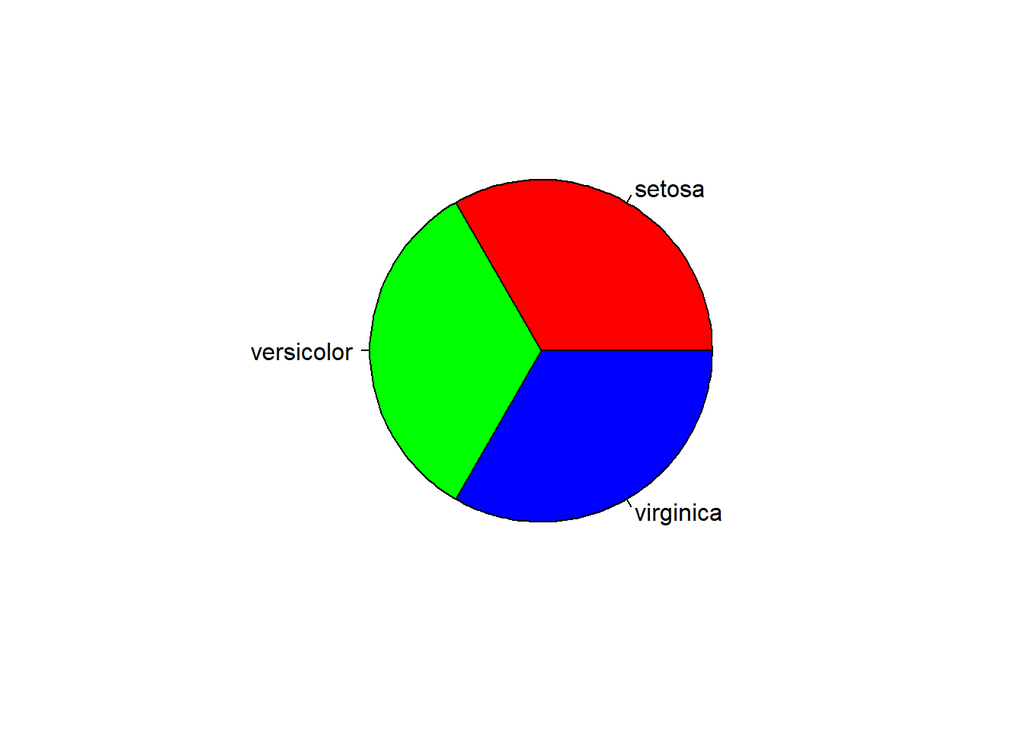

```r
pie(table(iris$Species), col=rainbow(3))
```

## 1.4 Box plot

Box plot can only be drawn for continuous variable.

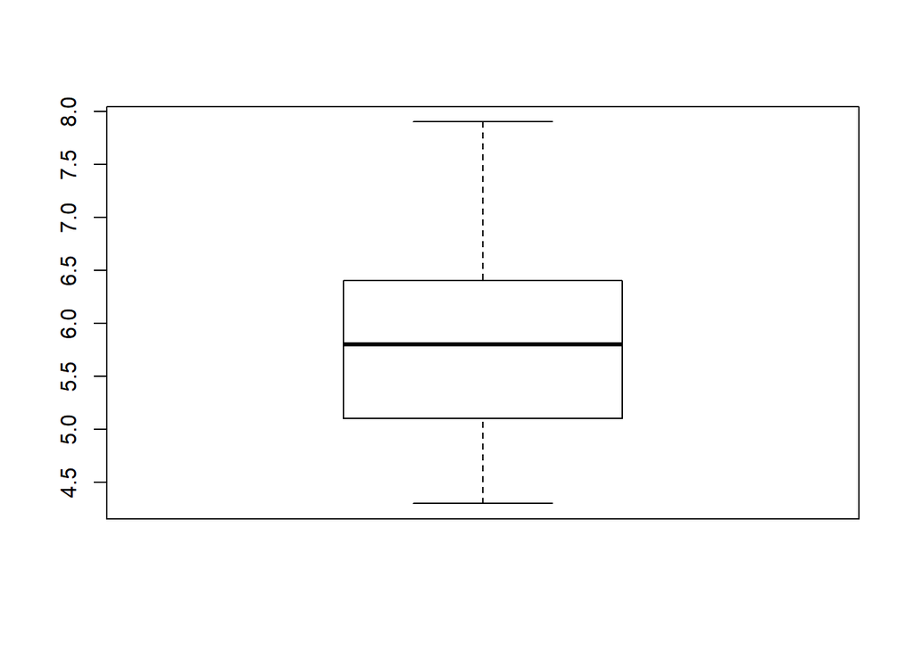

```r
# box plot of Sepal.Length
boxplot(iris$Sepal.Length)
```

#### 1.4.0.1 Draw box plot of multiple variables into one figure

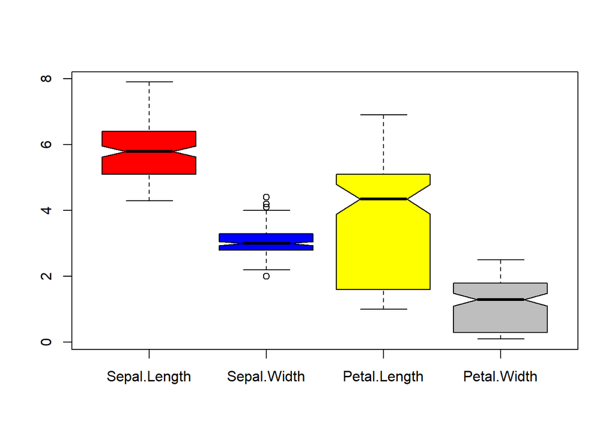

```r
boxplot(iris[,1:4], notch=T, col=c("red", "blue", "yellow", "grey"))
```

#### 1.4.0.2 Box plot by group

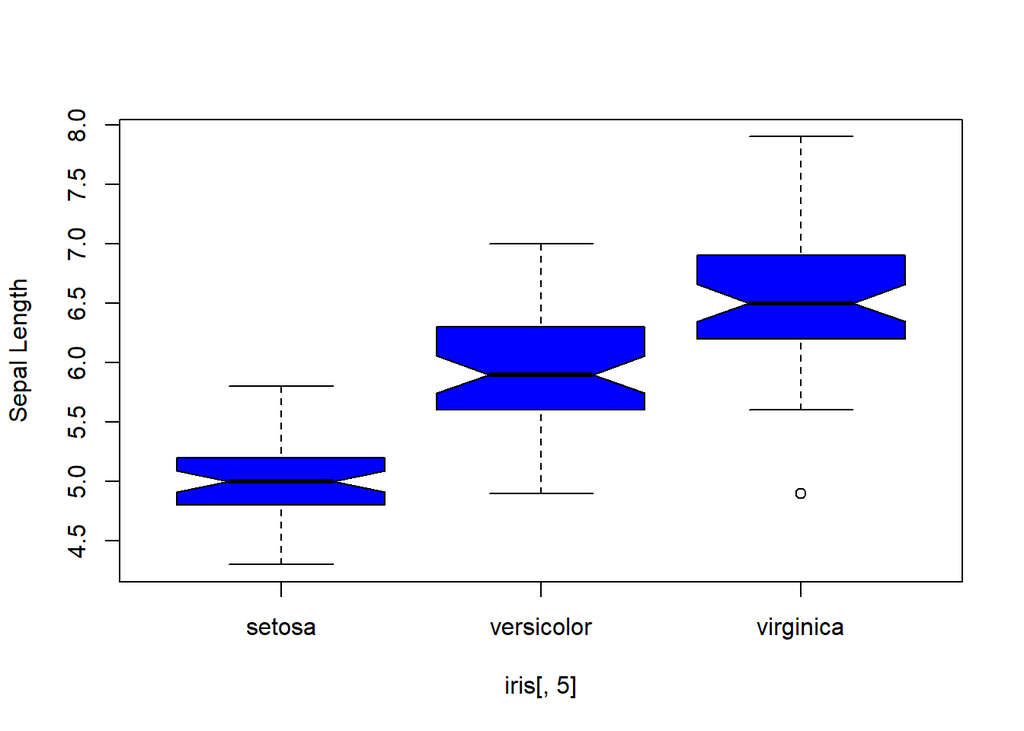

```r
boxplot(iris[,1]~iris[,5], notch=T, ylab="Sepal Length", col="blue")
```